# Projekt z Analizy Danych - Siłownia

Aleksandra Ochocińska

Mateusz Wasiewski

Adam Sienkiewicz

# **Wprowadzenie**

## **1. Wstęp**

## **2. Zmienne w zbiorze danych**

• *Wiek* - wiek użytkownika siłowni.

• *Płeć* - płeć użytkownika siłowni.

• *Waga* - waga użytkownika siłowni w kilogramach.

• *Wzrost* - wzrost użytkownika siłowni w metrach

• *Max_BPM* - maksymalne tętno podczas sesji treningowych.

• *Avg_BPM* - średnie tętno podczas sesji treningowych.

• *Resting_BPM* - tętno w spoczynku przed treningiem.

• *Session_Duration* - czas trwania każdej sesji treningowej w godzinach.

• *Calories_Burned* - całkowita liczba kalorii spalonych podczas każdej sesji.

• *Workout_Type* - rodzaj wykonanego treningu (np. kardio, siłowy, joga, HIIT).

• *Fat_Percentage* -procent tkanki tłuszczowej.

• *Water_Intake* - dzienne spożycie wody podczas treningu w litrach.

• *Workout_Frequency* - liczba sesji treningowych w tygodniu.

• *Experience_Level* - poziom doświadczenia, od początkującego (1) do eksperta (3).

• *BMI* - wskaźnik masy ciała, obliczany na podstawie wzrostu i wagi.

## **3. Struktura danych**

**1. Liczba kolumn oraz wierszy**

```
## Liczba wierszy: 973
```

```
## Liczba kolumn: 15
```

Zbiór danych siłownia posiada 973 wiersze oraz 15 kolumn.

**2. Statystki opisowe poszczególnych kolumn**

```
##       Age           Gender           Weight (kg)       Height (m)
##  Min.   :18.00   Length:973         Min.   : 40.00   Min.   :1.500
##  1st Qu.:28.00   Class :character   1st Qu.: 58.10   1st Qu.:1.620
##  Median :39.00   Mode  :character   Median : 70.00   Median :1.710
##  Mean   :38.63                      Mean   : 73.85   Mean   :1.723
##  3rd Qu.:50.00                      3rd Qu.: 86.00   3rd Qu.:1.800
##  Max.   :59.00                      Max.   :129.90   Max.   :2.000
##  NA's   :100
##     Max_BPM         Avg_BPM       Resting_BPM    Session_Duration (hours)
##  Min.   :160.0   Min.   :120.0   Min.   :50.00   Min.   :0.500
##  1st Qu.:170.0   1st Qu.:131.0   1st Qu.:56.00   1st Qu.:1.040
##  Median :180.0   Median :143.0   Median :62.00   Median :1.260
##  Mean   :179.9   Mean   :143.8   Mean   :62.22   Mean   :1.256
##  3rd Qu.:190.0   3rd Qu.:156.0   3rd Qu.:68.00   3rd Qu.:1.460
##  Max.   :199.0   Max.   :169.0   Max.   :74.00   Max.   :2.000
##
##  Calories_Burned  Workout_Type       Fat_Percentage  Water_Intake (liters)
##  Min.   : 303.0   Length:973         Min.   :10.00   Min.   :1.500
##  1st Qu.: 720.0   Class :character   1st Qu.:21.30   1st Qu.:2.200
##  Median : 893.0   Mode  :character   Median :26.20   Median :2.600
##  Mean   : 905.4                      Mean   :24.98   Mean   :2.627
##  3rd Qu.:1076.0                      3rd Qu.:29.30   3rd Qu.:3.100
##  Max.   :1783.0                      Max.   :35.00   Max.   :3.700
##
##  Workout_Frequency (days/week) Experience_Level      BMI
##  Min.   :2.000                 Min.   :1.00     Min.   :12.32
##  1st Qu.:3.000                 1st Qu.:1.00     1st Qu.:20.11
##  Median :3.000                 Median :2.00     Median :23.94
##  Mean   :3.322                 Mean   :1.81     Mean   :24.82
##  3rd Qu.:4.000                 3rd Qu.:2.00     3rd Qu.:28.45
##  Max.   :5.000                 Max.   :3.00     Max.   :47.72
##                                                 NA's   :150
```

## **4. Wstępne przygotowanie danych**

**1. Pobranie i zainstalowanie niezbędnych pakietów**

**2. Zmiana nazw kolumn**

Weight (kg) -> Weight_kg

Height (m) -> Height_m

Session_Duration (hours) -> Session_Duration_hours

Water_Intake (liters) -> Water_Intake_liters

Workout_Frequency (days/week) -> Workout_Frequency_daysweek

# **Data Wrangling**

## **1. Obserwacje odstające**

## **2. Analiza braków danych**

Analiza braków danych jest kluczowym etapem przygotowania zbioru danych do dalszej analizy. W ramach tego procesu określimy liczbę braków w zbiorze, przeanalizujemy ich rozmieszczenie oraz sprawdzimy, czy występują korelacje między brakami w różnych zmiennych. Wyniki tej analizy posłużą jako podstawa do podjęcia decyzji o dalszym postępowaniu z brakującymi danymi.

### **Wstępna analiza braków danych**

#### **Sprawdzenie gdzie występują braki danych i procentowo ile ich jest.**

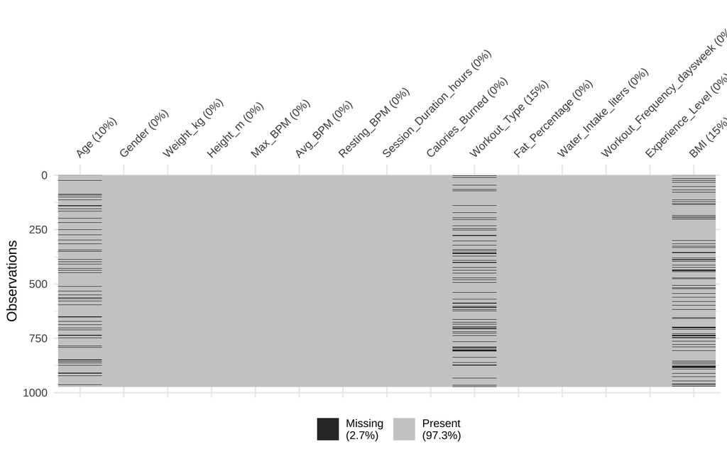

W całej bazie danych brakuje 2,7% danych.

Braki danych występują w kolumnie Workout_Type, Age oraz BMI.

#### **Ile braków jest w poszczególnych kolumnach**

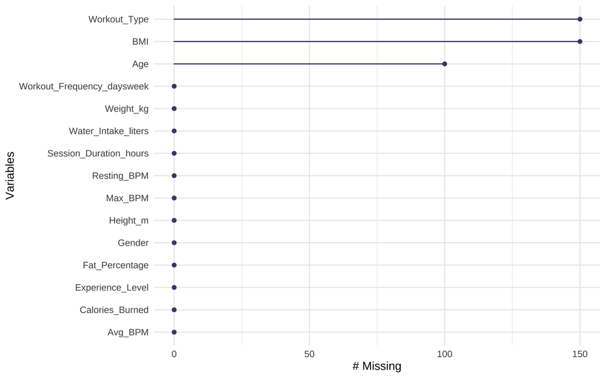

Kolumna Age ma 100 braków.

Kolumna Workout_Type ma 150 braków.

Kolumna BMI ma 150 braków.

#### **Występowanie braków w wierszach**

| Liczba NA w wierszu | Liczba wierszy | Procent wszystkich wierszy |
| --- | --- | --- |
| 0 | 631 | 64,85% |
| 1 | 287 | 29,50% |
| 2 | 52 | 5,34% |
| 3 | 3 | 0,31% |

631 wierszy ma 0 NA

287 wierszy ma 1 NA

- 115 w Workout_Type
- 106 w BMI
- 66 w Age

52 wiersze ma 2 NA

- 21 wierszy w Workout_Type i BMI
- 20 wierszy w Age i BMI
- 11 w Age i Workout_Type

3 wiersze mają 3 NA

#### **Sprawdzanie korelacji między brakami danych**

**1. Age i BMI**

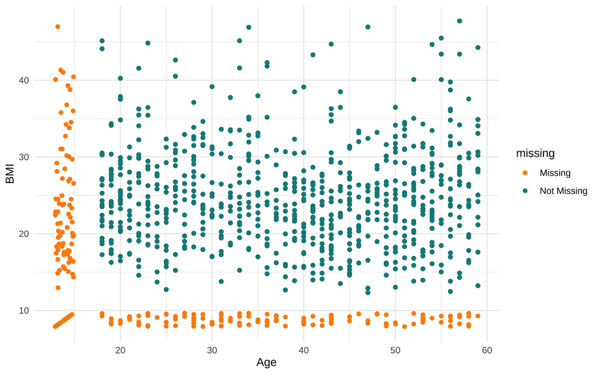

Braki w kolumnie BMI są całkowicie niezależne od wartości w kolumnie Age.

Z kolei braki w kolumnie Age są raczej niezależne od wartości BMI, choć zauważono nieco większą liczbę braków w przypadku niższych wartości BMI.

**2. Workout_Type i BMI**

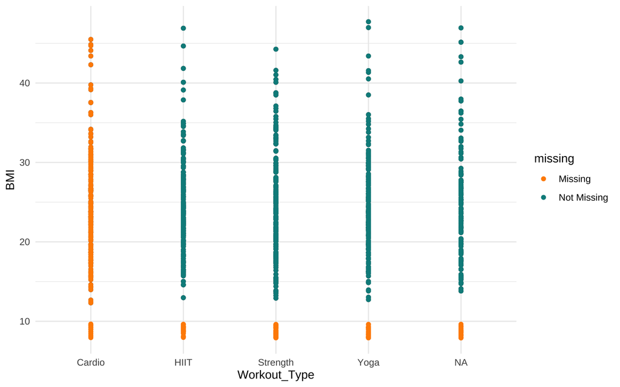

Braki w kolumnie BMI są całkowicie niezależne od wartości w kolumnie Workout_Type.

**3. Workout_Type i Age**

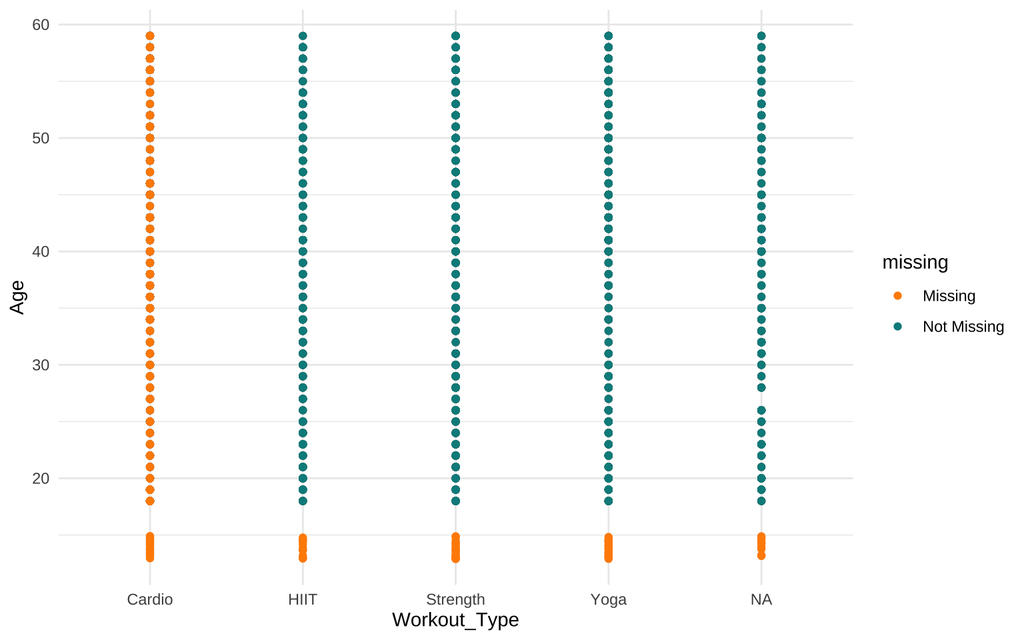

Braki w obu kolumnach są całkowicie niezależne od siebie.

## **3. Imputacja braków danych**

W procesie analizy dancyh napotkaliśmy na brakujące wartości (NA) w kolumnach **Age**, **BMI** oraz **Workout_Type**. Aby zapewnić spójność i pełność danych, postanowiliśmy przeprowadzić imputację braków, czyli zastąpienie brakujących wartości odpowiednimi danymi.

#### **Kolumna BMI**

Braki w kolumnie postanowaliśmy zastąpić za pomocą wzoru na BMI

$$BMI = \frac{waga}{wzrost^2}$$

```r
silownia$BMI <- ifelse(
  is.na(silownia$BMI),
  silownia$Weight_kg / (silownia$Height_m^2),
  silownia$BMI )
```

## **4. Walidacja danych**

# **Wizualizacja danych**

# **Analiza opisowa**

# **Wnioskowanie**

# **Podsumowanie**